# Reliability and Validity of Physics Playground

4/12/2021

## Physics Playground The Game

## Gameplay Sketching

[Sketching Levels](https://youtu.be/VGZ_QyDpXD8)

[figure not shown]

Physics Playground Sketching

Players draw objects (ramps, pendulums, levers, springboards) to get ball to balloon.

## Gameplay Manipulation

[Manipulation Levels](https://youtu.be/TzDvJRFweKM)

[figure not shown]

Physics Playground Manipulation

Players manipulate physics parameters (gravity, ball mass, air resistance, bounciness) to get ball to balloon.

## Four Process Architecture

- **Presentation** (Game Engine) – Presents game level captures *work product* (collection of events).
- **Evidence Identification** (Server) – Processes events for a game level to create observable evidence sets for the game levels.
- **Evidence Accumulation** (Server) – Uses Bayesian networks to estimate physics proficiencies from game levels.
- **Activity Selection** (Game Engine) – Picks next game level based on current ability estimates.

Note: Events and evidence sets are stored in a database, so scoring can easily be rerun by marking evidence sets as “unprocessed” and reprocessing.

## Physics Playground Model

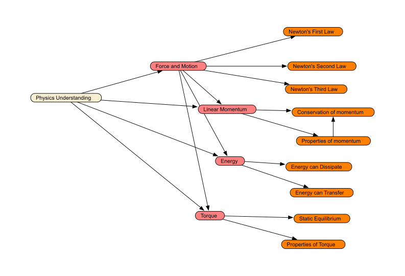

Proficiency Model

- 4 high-level proficiencies (salmon)
- 9 low-level proficiencies (orange).

Each nodes has states `High`, `Medium` and `Low`.

## Physics Playground Q-Matrix

There is a collection of evidence models: one for each game level.

These are represented through an augmented Q-matrix

[online sheet](https://docs.google.com/spreadsheets/d/16LcEuCspZjiBoZ3-Y1R3jxi1COXmh9vuTa9GwH1A_7Q/)

[Peanut package](https://pluto.coe.fsu.edu/RNetica/Peanut.html) has code for building Bayes nets from spreadsheet.

## Physics Playground Scores

- *Margin* – Probabilities for `High`, `Medium` and `Low` (vector valued).
- *Mode* – One of `High`, `Medium` or `Low` with highest probability.
- *EAP (Expected A Posteriori)* – Assign the value +1 to `High`, 0 to `Medium` and -1 to `Low` and then calculate the expected value. This can be also expressed as \(\Pr(High) -\Pr(Low)\). The score runs from +1 (high) to -1 (low). (In the implementation, .97 and -.97 was used, so the actual scores do not every quite reach +1 or -1).

[EABN Engine](https://pluto.coe.fsu.edu/Proc4) can spit out each of these score types for each node.

## Reliability

## Split Halfs

- “Items” are game levels: need to leave game levels intact.
- Pair game levels on:
  - Primary and Secondary Skills
  - Difficulty
  - Other features
- Randomly assign one level of each pair to *Form A* and *Form B*.

## Rescoring Logic

- Mark observable sets from *Form A* levels as unscored. Rescore to get *Form A* scores.
- Mark observable sets from *Form B* levels as unscored. Rescore to get *Form B* scores.

## Reliabilities: EAP correlations

EAP scores are continuous, so can use ordinary correlations.

Optionally apply Spearman-Brown corrections

Correlations between Form A and B sub-forms.

| Measure | Reliability |
| --- | --- |
| Physics | 0.229 |
| Force and Motion | 0.135 |
| Linear Momentum | 0.080 |
| Energy | 0.456 |
| Torque | 0.139 |

## Scatterplot (Higher Reliability)

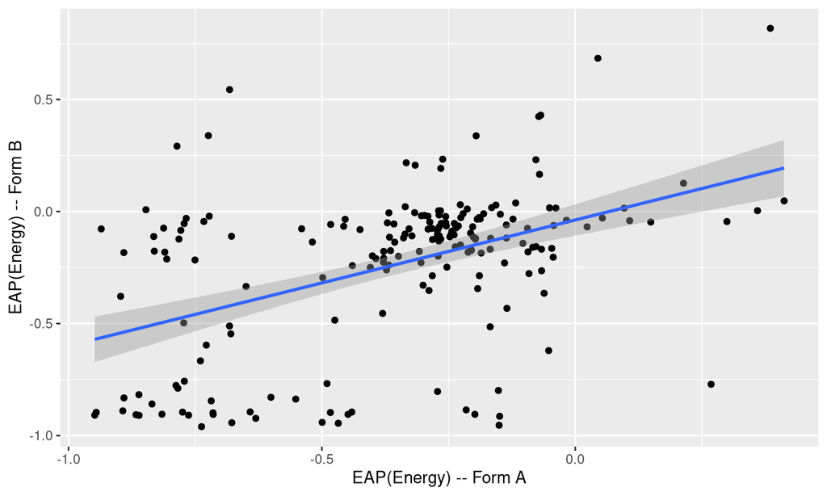

Energy EAP score consistency

## Scatterplot (Lower Reliability)

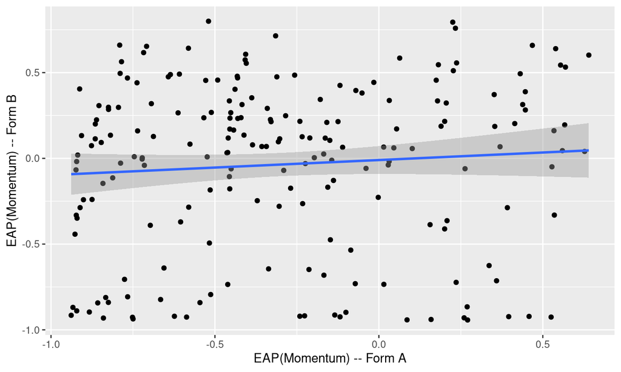

Linear Momentum EAP score consistency

## Reliabilities: Modal Kappas

```r
modalTab <- table(statAB$Physics_ModeA,statAB$Physics_ModeB)
```

Agreement of Physics Modal Scores.

|  | L | M |
| --- | --- | --- |
| L | 53 | 89 |
| M | 17 | 40 |

```
## Call: cohen.kappa1(x = x, w = w, n.obs = n.obs, alpha = alpha, levels = levels)
##
## Cohen Kappa and Weighted Kappa correlation coefficients and confidence boundaries
##                  lower estimate upper
## unweighted kappa -0.05    0.054  0.16
## weighted kappa   -0.05    0.054  0.16
##
##  Number of subjects = 199
```

The `cohen.kappa` function is from the `psych` package.

## Expected Kappas (1)

Get the “expected agreement” table by multiplying the margin scores together.

```r
statAB[1,paste("Physics_Margin.",c("High","Medium","Low"),"A",sep="")]
```

```
##   Physics_Margin.HighA Physics_Margin.MediumA Physics_Margin.LowA
## 1               0.0323                 0.6432              0.3244
```

```r
statAB[1,paste("Physics_Margin.",c("High","Medium","Low"),"B",sep="")]
```

```
##   Physics_Margin.HighB Physics_Margin.MediumB Physics_Margin.LowB
## 1                5e-04                 0.0941              0.9055
```

## Expected Kappas (2)

```r
outer(
  as.numeric(statAB[1,paste("Physics_Margin.",c("High","Medium","Low"),"A",sep="")]),
  as.numeric(statAB[1,paste("Physics_Margin.",c("High","Medium","Low"),"B",sep="")])
)
```

```
##           [,1]       [,2]       [,3]
## [1,] 1.615e-05 0.00303943 0.02924765
## [2,] 3.216e-04 0.06052512 0.58241760
## [3,] 1.622e-04 0.03052604 0.29374420
```

## Expected Kappas (3)

Now sum accros students:

```r
states <- c("High","Medium","Low")
expTab <- outer(
  as.numeric(statAB[1,paste("Physics_Margin.",states,"A",sep="")]),
  as.numeric(statAB[1,paste("Physics_Margin.",states,"B",sep="")])
)
for (irow in 2:(nrow(statAB))) {
  itab <- outer(
  as.numeric(statAB[irow,paste("Physics_Margin.",states,"A",sep="")]),
  as.numeric(statAB[irow,paste("Physics_Margin.",states,"B",sep="")])
  )
  if (all(!is.na(itab)))
    expTab <- expTab + itab
}
rownames(expTab) <- states
colnames(expTab) <- states
```

## Expected Kappas (4)

Agreement of Physics Marginal Scores.

|  | High | Medium | Low |
| --- | --- | --- | --- |
| High | 0.111 | 1.482 | 1.061 |
| Medium | 2.837 | 42.651 | 29.662 |
| Low | 3.485 | 62.450 | 55.261 |

```
## Call: cohen.kappa1(x = x, w = w, n.obs = n.obs, alpha = alpha, levels = levels)
##
## Cohen Kappa and Weighted Kappa correlation coefficients and confidence boundaries
##                   lower estimate upper
## unweighted kappa -0.073    0.050  0.17
## weighted kappa   -0.357    0.057  0.47
##
##  Number of subjects = 199
```

## Validity

## Correlations with external measures

The Fall 2019 Field trial included a pret-test and post-test.

Items were coded to subscales matching the 4 high-level (salmon) nodes.

Correlation of Physics EAP score with whole pretest and posttest.

|  | preScore | postScore | Physics_EAP |
| --- | --- | --- | --- |
| preScore | 1.000 | 0.698 | 0.226 |
| postScore | 0.698 | 1.000 | 0.182 |
| Physics_EAP | 0.226 | 0.182 | 1.000 |

## Subscales

As the subscale measures are short, sum the pre -test and post-test scores

Reliability (sub-form correlations) and Valitity (corrlation with pretest + posttest)

| Measure | Reliability | Validity |
| --- | --- | --- |
| Physics | 0.229 | 0.220 |
| Force and Motion | 0.135 | 0.153 |
| Linear Momentum | 0.080 | 0.061 |
| Energy | 0.456 | 0.223 |
| Torque | 0.139 | 0.174 |

## Eta Statistic

Can use the \(\eta\) or \(\eta^2\) statistic to show how much of variability in score is explained by classification.

```r
## AOV expect factors.
BSEAP$Physics_Mode <- factor(BSEAP$Physics_Mode)
## Pretest
preaov <- aov(preScore ~ Physics_Mode,data=BSEAP)
cat("Pretest eta:", round(
  sqrt(eta_squared(preaov, partial=FALSE)$Eta_Sq),
 digits=2),"\n")
```

```
## Pretest eta: 0.17
```

[output not shown]

The `eta_squared` function is from the `effectsize` package.

## Discussion

These techniques work with any CDM which provides probability distributions over mastery states.

ECD models really help to produce matched forms for split-halfs.

These calculations can be used in formatory analysis.

Can do this with simulated data to examine form designs.

## Resources

- Physics Playground: https://pluto.coe.fsu.edu/ppteam/
- RNetica and Peanut (Bayes net tools): https://pluto.coe.fsu.edu/RNetica
- Four Process Scoring Tools: https://pluto.coe.fsu.edu/Proc4
- Russell’s Github page: https://github.com/ralmond